# Tercera entrega — Modelado y evaluación

Calidad del aire en CABA · UTN FRC · Grupo 12

Tres regresiones (CO, NO₂ y PM10) y clasificación diaria por estación. Se comparan referencia, Random Forest y XGBoost. Este notebook presenta resultados calculados, con código reproducible.

```python
from pathlib import Path
import json
import sys
import pandas as pd
from IPython.display import display, Image, Markdown
ROOT = Path.cwd().parent if Path.cwd().name == "notebooks" else Path.cwd()
sys.path.insert(0, str(ROOT))
OUT = ROOT / "outputs/tercera_entrega"
report = json.loads((OUT / "reporte.json").read_text(encoding="utf-8"))
audit = json.loads((OUT / "auditoria.json").read_text(encoding="utf-8"))
pd.set_option("display.max_columns", 20)
print("Filas de entrada:", audit["input_rows"])
print("Cobertura diaria:", report["coverage"])
```

```
Filas de entrada: 398961
Cobertura diaria: {'station_days_available': 17108, 'eligible_station_days': 10085, 'excluded_station_days': 7023, 'minimum_hours_per_pollutant': 18, 'required_predictor_hours': 24}
```

## 1. Dataset y decisiones

Entrada: dataset_objetivo_listo_modelar.csv, con one-hot de estación, día de semana, mes y hora. Las fechas identifican y dividen períodos, pero no son predictores directos. Para cada regresión se excluyen los tres contaminantes de las entradas y se filtran los objetivos sin dato, interpolados o fuera de los límites del notebook de segunda entrega. Los censurados conservan LD/2.

Los máximos de plausibilidad son reglas del proyecto: CO 10 ppm, NO₂ 400 ppb y PM10 600 µg/m³. Los valores altos dentro de esos límites se conservan.

```python
display(pd.DataFrame(audit["original_outliers"]["by_station"]))
display(pd.DataFrame(audit["targets"]).T)
print("Columnas predictoras horarias:", len(report["features"]["hourly"]))
```

|  | pollutant | station | maximum_allowed | above_maximum | maximum_observed |
| --- | --- | --- | --- | --- | --- |
| 0 | CO | centenario | 10.0 | 103 | 49.95 |
| 1 | CO | cordoba | 10.0 | 96 | 47.29 |
| 2 | CO | la_boca | 10.0 | 122 | 44.73 |
| 3 | NO2 | centenario | 400.0 | 0 | 155.00 |
| 4 | NO2 | cordoba | 400.0 | 0 | 283.00 |
| 5 | NO2 | la_boca | 400.0 | 0 | 129.00 |
| 6 | PM10 | centenario | 600.0 | 0 | 427.00 |
| 7 | PM10 | cordoba | 600.0 | 0 | 253.00 |
| 8 | PM10 | la_boca | 600.0 | 0 | 387.00 |

|  | plausibility_range | missing_in_input | invalid_in_input | interpolated_excluded | usable |
| --- | --- | --- | --- | --- | --- |
| CO | [0.0, 10.0] | 60209 | 0 | 60 | 338692 |
| NO2 | [0.0, 400.0] | 63181 | 0 | 2747 | 333033 |
| PM10 | [0.0, 600.0] | 67680 | 0 | 32 | 331249 |

```
Columnas predictoras horarias: 59
```

## 2. Etiquetas EPA adaptadas

| Clase | CO (ppm) | NO₂ (ppb) | PM10 (µg/m³) |
| --- | --- | --- | --- |
| Buena | 0–4,4 | 0–53 | 0–54 |
| Moderada | 4,5–9,4 | 54–100 | 55–154 |
| Desfavorable, agrupada | ≥9,5 | ≥101 | ≥155 |

Se aplica el truncamiento EPA: CO a un decimal; NO₂ y PM10 a enteros. Las categorías EPA desde 101 se agrupan como Desfavorable. Los datos publicados ya son CO móvil 8 h, NO₂ 1 h y PM10 móvil 24 h; no se recalculan esas ventanas. La etiqueta diaria es la peor categoría entre los registros del día y los tres contaminantes. Esto es una adaptación del proyecto y no reproduce el AQI diario oficial.

Cada estación-día necesita al menos 18 horas válidas de cada contaminante y las 24 filas meteorológicas. Los conteos y categorías observadas no entran como predictores. Las variables meteorológicas diarias se resumen con media, mínimo y máximo; además se suma la precipitación.

| category split | Buena | Desfavorable | Moderada |
| --- | --- | --- | --- |
| purga | 6 | 0 | 0 |
| test | 1419 | 0 | 83 |
| train | 7121 | 34 | 897 |
| validation | 472 | 0 | 53 |

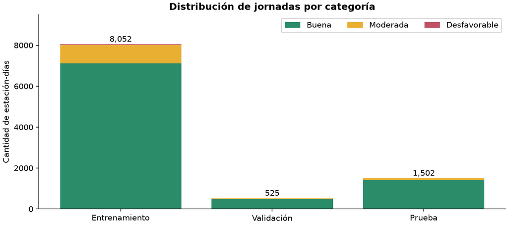

```python
distribution = pd.read_csv(OUT / "distribucion_categorias.csv")
display(distribution.query("level == 'daily'").pivot_table(index="split", columns="category", values="count", aggfunc="sum", fill_value=0))
display(Image(filename=str(OUT / "figuras/distribucion_diaria.png")))
```

## 3. Partición temporal

Entrenamiento anterior a 2024; validación en 2024; prueba desde 2025. Se purgan dos días al final de entrenamiento y validación para separar ventanas vecinas. Los cortes son comunes a todas las estaciones. Los parámetros se eligen con validación; la prueba no participa en la selección.

```python
display(pd.DataFrame({"horario": report["splits_hourly"], "diario": report["splits_daily"]}).fillna(0).astype(int))
display(pd.Series(report["config"], name="Configuración"))
```

|  | horario | diario |
| --- | --- | --- |
| train | 332365 | 8052 |
| test | 41606 | 1502 |
| validation | 24702 | 525 |
| purga | 288 | 6 |

```
seed                                                                                42
threads                                                                              4
validation_start                                                            2024-01-01
test_start                                                                  2025-01-01
gap_days                                                                             2
minimum_daily_hours                                                                 18
daily_predictor_hours                                                               24
regression_forest                    {'n_estimators': 200, 'max_depth': 16, 'min_sa...
regression_xgboost_candidates        [{'n_estimators': 400, 'max_depth': 3, 'learni...
classification_forest                {'n_estimators': 300, 'max_depth': 12, 'min_sa...
classification_xgboost_candidates    [{'n_estimators': 300, 'max_depth': 3, 'learni...
xgboost_common                       {'subsample': 0.8, 'colsample_bytree': 0.8, 'r...
Name: Configuración, dtype: object
```

## 4. Algoritmos y parámetros

Regresión: mediana por estación, Random Forest Regressor y XGBoost Regressor. Clasificación diaria: clase mayoritaria, Random Forest Classifier y XGBoost Classifier. Las clases se balancean únicamente durante el ajuste de los clasificadores, con pesos calculados en entrenamiento. Las métricas conservan la distribución natural de validación y prueba. No se crean muestras sintéticas.

Se prueban dos configuraciones XGBoost. Se elige por MAE para regresión y F1 macro para clasificación. Las predicciones de concentración negativas se limitan a cero; las observaciones no se rellenan.

```python
display(pd.DataFrame(report["tuning_trials"]))
display(report["parameters"])
display(report["selected_by_validation"])
```

|  | task | candidate | validation_mae | parameters | validation_f1_macro |
| --- | --- | --- | --- | --- | --- |
| 0 | CO | 0 | 0.168789 | {'n_estimators': 400, 'max_depth': 3, 'learnin... | NaN |
| 1 | CO | 1 | 0.165469 | {'n_estimators': 600, 'max_depth': 5, 'learnin... | NaN |
| 2 | NO2 | 0 | 6.330191 | {'n_estimators': 400, 'max_depth': 3, 'learnin... | NaN |
| 3 | NO2 | 1 | 5.406378 | {'n_estimators': 600, 'max_depth': 5, 'learnin... | NaN |
| 4 | PM10 | 0 | 8.552640 | {'n_estimators': 400, 'max_depth': 3, 'learnin... | NaN |
| 5 | PM10 | 1 | 8.658601 | {'n_estimators': 600, 'max_depth': 5, 'learnin... | NaN |
| 6 | daily | 0 | NaN | {'n_estimators': 300, 'max_depth': 3, 'learnin... | 0.423267 |
| 7 | daily | 1 | NaN | {'n_estimators': 500, 'max_depth': 4, 'learnin... | 0.455113 |

```
{'regression': {'CO_Referencia': {'strategy': 'median_per_station'},
  'CO_RandomForest': {'n_estimators': 200,
   'max_depth': 16,
   'min_samples_leaf': 10,
   'max_features': 0.8},
  'CO_XGBoost': {'n_estimators': 600,
   'max_depth': 5,
   'learning_rate': 0.05,
   'subsample': 0.8,
   'colsample_bytree': 0.8,
   'reg_lambda': 5.0,
   'tree_method': 'hist'},
  'NO2_Referencia': {'strategy': 'median_per_station'},
  'NO2_RandomForest': {'n_estimators': 200,
   'max_depth': 16,
   'min_samples_leaf': 10,
   'max_features': 0.8},
  'NO2_XGBoost': {'n_estimators': 600,
   'max_depth': 5,
   'learning_rate': 0.05,
   'subsample': 0.8,
   'colsample_bytree': 0.8,
   'reg_lambda': 5.0,
   'tree_method': 'hist'},
  'PM10_Referencia': {'strategy': 'median_per_station'},
  'PM10_RandomForest': {'n_estimators': 200,
   'max_depth': 16,
   'min_samples_leaf': 10,
   'max_features': 0.8},
  'PM10_XGBoost': {'n_estimators': 400,
   'max_depth': 3,
   'learning_rate': 0.05,
   'subsample': 0.8,
   'colsample_bytree': 0.8,
   'reg_lambda': 5.0,
   'tree_method': 'hist'}},
 'daily': {'Referencia': {'strategy': 'most_frequent'},
  'RandomForest': {'n_estimators': 300,
   'max_depth': 12,
   'min_samples_leaf': 5,
   'max_features': 0.8,
   'class_weight': 'balanced_subsample'},
  'XGBoost': {'n_estimators': 500,
   'max_depth': 4,
   'learning_rate': 0.05,
   'subsample': 0.8,
   'colsample_bytree': 0.8,
   'reg_lambda': 5.0,
   'tree_method': 'hist',
   'sample_weight': 'balanced_train'}}}
```

```
{'regression': {'CO': 'XGBoost', 'NO2': 'XGBoost', 'PM10': 'Referencia'},
 'daily': 'XGBoost'}
```

## 5. Evaluación de concentraciones

MAE y RMSE se expresan en las unidades de cada contaminante; R² es complementario. MAE_high mide el error en concentraciones que superan el percentil 90 de entrenamiento. También se evalúan las categorías derivadas de cada predicción horaria.

|  | task | model | n | mae | rmse | r2 | mae_high |
| --- | --- | --- | --- | --- | --- | --- | --- |
| 4 | CO | Referencia | 41189 | 0.167647 | 0.242556 | 0.171583 | 0.604207 |
| 12 | CO | RandomForest | 41189 | 0.147277 | 0.201480 | 0.428407 | 0.407010 |
| 20 | CO | XGBoost | 41189 | 0.134524 | 0.187494 | 0.505005 | 0.369896 |
| 28 | NO2 | Referencia | 40719 | 8.132469 | 10.520908 | -0.092420 | 24.499836 |
| 36 | NO2 | RandomForest | 40719 | 6.793442 | 8.491170 | 0.288429 | 9.738897 |
| 44 | NO2 | XGBoost | 40719 | 6.104255 | 7.635340 | 0.424640 | 8.628569 |
| 52 | PM10 | Referencia | 38003 | 7.491566 | 10.113614 | 0.010238 | 26.209542 |
| 60 | PM10 | RandomForest | 38003 | 8.489865 | 11.074012 | -0.186664 | 21.113403 |
| 68 | PM10 | XGBoost | 38003 | 7.944199 | 10.162589 | 0.000629 | 20.562402 |

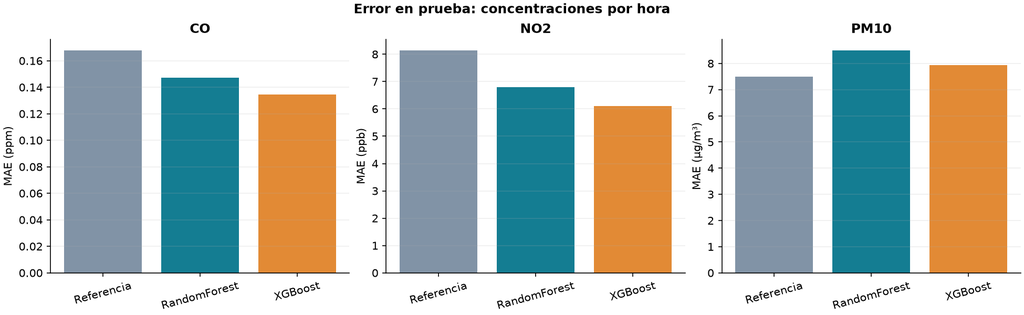

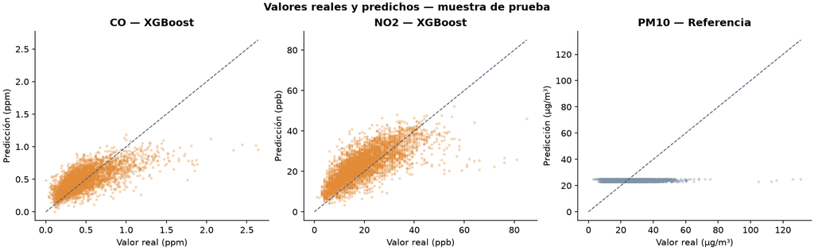

```python
reg = pd.read_csv(OUT / "metricas_regresion.csv")
display(reg.query("split == 'test' and station == 'todas'")[["task","model","n","mae","rmse","r2","mae_high"]])
display(Image(filename=str(OUT / "figuras/mae_regresion.png")))
display(Image(filename=str(OUT / "figuras/reales_predichos.png")))
```

```python
display(reg.query("split == 'test' and station != 'todas'")[["task","model","station","n","mae","rmse","r2"]])
```

|  | task | model | station | n | mae | rmse | r2 |
| --- | --- | --- | --- | --- | --- | --- | --- |
| 5 | CO | Referencia | centenario | 13845 | 0.162445 | 0.218153 | -0.012739 |
| 6 | CO | Referencia | cordoba | 13818 | 0.233770 | 0.321361 | -0.091420 |
| 7 | CO | Referencia | la_boca | 13526 | 0.105420 | 0.157932 | -0.030487 |
| 13 | CO | RandomForest | centenario | 13845 | 0.147241 | 0.187894 | 0.248717 |
| 14 | CO | RandomForest | cordoba | 13818 | 0.187515 | 0.255402 | 0.310628 |
| 15 | CO | RandomForest | la_boca | 13526 | 0.106207 | 0.144363 | 0.138980 |
| 21 | CO | XGBoost | centenario | 13845 | 0.136845 | 0.177849 | 0.326899 |
| 22 | CO | XGBoost | cordoba | 13818 | 0.170158 | 0.236141 | 0.410687 |
| 23 | CO | XGBoost | la_boca | 13526 | 0.095746 | 0.133071 | 0.268412 |
| 29 | NO2 | Referencia | centenario | 13874 | 6.087574 | 7.345011 | -0.137686 |
| 30 | NO2 | Referencia | cordoba | 13325 | 7.579737 | 9.302545 | -0.116183 |
| 31 | NO2 | Referencia | la_boca | 13520 | 10.775666 | 13.882338 | -0.731332 |
| 37 | NO2 | RandomForest | centenario | 13874 | 6.281748 | 7.297584 | -0.123042 |
| 38 | NO2 | RandomForest | cordoba | 13325 | 6.476346 | 8.528235 | 0.061897 |
| 39 | NO2 | RandomForest | la_boca | 13520 | 7.631055 | 9.529790 | 0.184128 |
| 45 | NO2 | XGBoost | centenario | 13874 | 5.958293 | 6.995024 | -0.031849 |
| 46 | NO2 | XGBoost | cordoba | 13325 | 5.961607 | 7.810679 | 0.213118 |
| 47 | NO2 | XGBoost | la_boca | 13520 | 6.394629 | 8.077286 | 0.413881 |
| 53 | PM10 | Referencia | centenario | 13329 | 7.099332 | 9.122358 | -0.023932 |
| 54 | PM10 | Referencia | cordoba | 12612 | 6.773945 | 9.792175 | -0.018829 |
| 55 | PM10 | Referencia | la_boca | 12062 | 8.675344 | 11.403775 | -0.004494 |
| 61 | PM10 | RandomForest | centenario | 13329 | 8.088442 | 9.896109 | -0.204996 |
| 62 | PM10 | RandomForest | cordoba | 12612 | 7.015425 | 9.622221 | 0.016230 |
| 63 | PM10 | RandomForest | la_boca | 12062 | 10.475126 | 13.466466 | -0.400739 |
| 69 | PM10 | XGBoost | centenario | 13329 | 7.597396 | 9.323861 | -0.069666 |
| 70 | PM10 | XGBoost | cordoba | 12612 | 6.522199 | 9.147110 | 0.110982 |
| 71 | PM10 | XGBoost | la_boca | 12062 | 9.814270 | 11.909722 | -0.095603 |

## 6. Clasificación: métricas requeridas

Se informan matriz de confusión, precision, recall, F1-score, accuracy y tasa de falsos positivos. Para cada clase: FPR = FP / (FP + TN), considerando esa clase frente al resto. Se agregan balanced accuracy y F1 ponderado como complementos.

El F1 macro principal promedia las tres clases fijas. El F1 macro_supported sólo promedia clases con casos reales. Una clase sin soporte no tiene recall evaluable: en el detalle figura vacío. No se interpreta un FPR bajo ni una accuracy alta como evidencia de detectar eventos ausentes.

|  | split | model | n | accuracy | precision_macro | recall_macro | f1_macro | f1_macro_supported | balanced_accuracy | false_positive_rate_macro |
| --- | --- | --- | --- | --- | --- | --- | --- | --- | --- | --- |
| 72 | validation | Referencia | 525 | 0.899048 | 0.299683 | 0.333333 | 0.315614 | 0.473420 | 0.500000 | 0.333333 |
| 76 | test | Referencia | 1502 | 0.944740 | 0.314913 | 0.333333 | 0.323862 | 0.485793 | 0.500000 | 0.333333 |
| 80 | validation | RandomForest | 525 | 0.908571 | 0.508000 | 0.420611 | 0.445078 | 0.667616 | 0.630916 | 0.246056 |
| 84 | test | RandomForest | 1502 | 0.910786 | 0.389396 | 0.393195 | 0.391205 | 0.586807 | 0.589793 | 0.273472 |
| 88 | validation | XGBoost | 525 | 0.880000 | 0.450565 | 0.460265 | 0.455113 | 0.682670 | 0.690398 | 0.206401 |
| 92 | test | XGBoost | 1502 | 0.884820 | 0.380396 | 0.410502 | 0.389620 | 0.584429 | 0.615753 | 0.256165 |

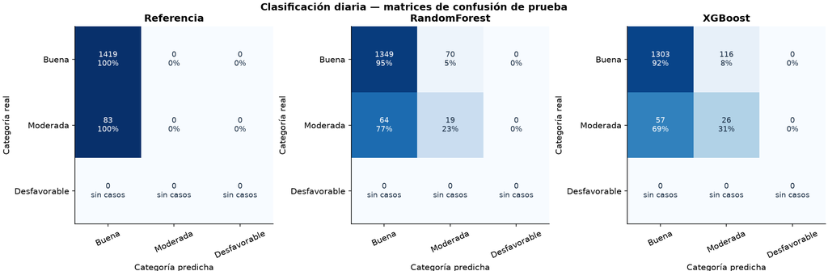

```python
cls = pd.read_csv(OUT / "metricas_clasificacion.csv")
display(cls.query("task == 'daily' and station == 'todas'")[["split","model","n","accuracy","precision_macro","recall_macro","f1_macro","f1_macro_supported","balanced_accuracy","false_positive_rate_macro"]])
display(Image(filename=str(OUT / "figuras/matrices_diarias.png")))
```

```python
detail = pd.read_csv(OUT / "metricas_por_clase.csv")
winner = report["selected_by_validation"]["daily"]
display(detail.query("task == 'daily' and split == 'test' and station == 'todas' and model == @winner")[["category","support","precision","recall","f1","false_positive_rate","tp","fp","fn","tn"]])
display(cls.query("task == 'daily' and split == 'test' and station != 'todas'")[["model","station","n","accuracy","f1_macro","f1_macro_supported","false_positive_rate_macro"]])
```

|  | category | support | precision | recall | f1 | false_positive_rate | tp | fp | fn | tn |
| --- | --- | --- | --- | --- | --- | --- | --- | --- | --- | --- |
| 276 | Buena | 1419 | 0.958088 | 0.918252 | 0.937747 | 0.686747 | 1303 | 57 | 116 | 26 |
| 277 | Moderada | 83 | 0.183099 | 0.313253 | 0.231111 | 0.081748 | 26 | 116 | 57 | 1303 |
| 278 | Desfavorable | 0 | NaN | NaN | NaN | 0.000000 | 0 | 0 | 0 | 1502 |

|  | model | station | n | accuracy | f1_macro | f1_macro_supported | false_positive_rate_macro |
| --- | --- | --- | --- | --- | --- | --- | --- |
| 77 | Referencia | centenario | 535 | 0.985047 | 0.330822 | 0.496234 | 0.333333 |
| 78 | Referencia | cordoba | 489 | 0.957055 | 0.326019 | 0.489028 | 0.333333 |
| 79 | Referencia | la_boca | 478 | 0.887029 | 0.313378 | 0.470067 | 0.333333 |
| 85 | RandomForest | centenario | 535 | 0.975701 | 0.373670 | 0.560506 | 0.295462 |
| 86 | RandomForest | cordoba | 489 | 0.920245 | 0.335719 | 0.503579 | 0.330993 |
| 87 | RandomForest | la_boca | 478 | 0.828452 | 0.398495 | 0.597742 | 0.263772 |
| 93 | XGBoost | centenario | 535 | 0.955140 | 0.351312 | 0.526967 | 0.302419 |
| 94 | XGBoost | cordoba | 489 | 0.889571 | 0.347059 | 0.520588 | 0.311355 |
| 95 | XGBoost | la_boca | 478 | 0.801255 | 0.400089 | 0.600134 | 0.247059 |

## 7. Patrones e interpretación

Las importancias se agrupan para reunir las columnas de una misma variable one-hot o de sus resúmenes meteorológicos. Describen la utilización de entradas por el modelo y no relaciones causales.

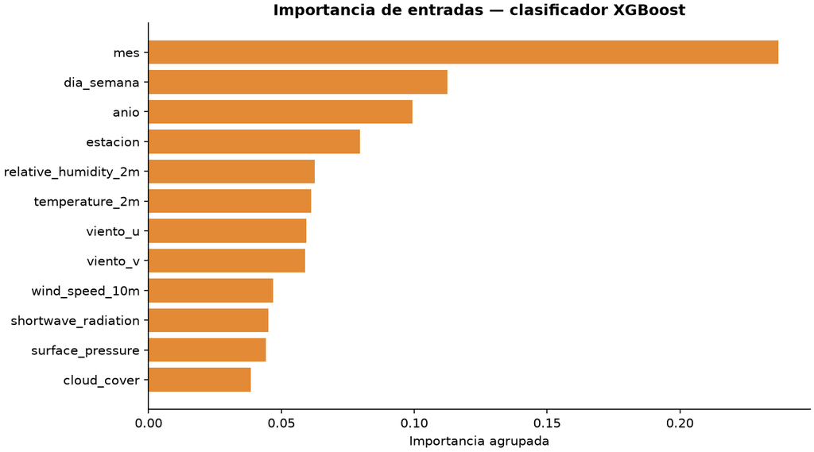

Tercera entrega: resultados e interpretación

Se compararon una referencia simple, Random Forest y XGBoost. Los modelos se eligieron por validación, antes de evaluar la prueba.

Se identificaron 321 valores originales por encima de los máximos de plausibilidad, todos de CO. Ya estaban invalidados en el ETL. No se reintrodujeron valores interpolados como objetivos.

Regresión de concentraciones

| task | model | mae | rmse | r2 | mae_high |
| --- | --- | --- | --- | --- | --- |
| CO | Referencia | 0.1676 | 0.2426 | 0.1716 | 0.6042 |
| CO | RandomForest | 0.1473 | 0.2015 | 0.4284 | 0.4070 |
| CO | XGBoost | 0.1345 | 0.1875 | 0.5050 | 0.3699 |
| NO2 | Referencia | 8.1325 | 10.5209 | -0.0924 | 24.4998 |
| NO2 | RandomForest | 6.7934 | 8.4912 | 0.2884 | 9.7389 |
| NO2 | XGBoost | 6.1043 | 7.6353 | 0.4246 | 8.6286 |
| PM10 | Referencia | 7.4916 | 10.1136 | 0.0102 | 26.2095 |
| PM10 | RandomForest | 8.4899 | 11.0740 | -0.1867 | 21.1134 |
| PM10 | XGBoost | 7.9442 | 10.1626 | 0.0006 | 20.5624 |

- CO: validación seleccionó XGBoost. MAE de prueba 0.1345; diferencia respecto de la referencia: 19.8% de reducción del MAE. El MAE varía entre 0.0957 en la_boca y 0.1702 en cordoba.

- NO2: validación seleccionó XGBoost. MAE de prueba 6.1043; diferencia respecto de la referencia: 24.9% de reducción del MAE. El MAE varía entre 5.9583 en centenario y 6.3946 en la_boca.

- PM10: validación seleccionó Referencia. MAE de prueba 7.4916; diferencia respecto de la referencia: 0.0% de reducción del MAE. El MAE varía entre 6.7739 en cordoba y 8.6753 en la_boca.

Clasificación diaria

| model | n | accuracy | precision_macro | recall_macro | f1_macro | f1_macro_supported | false_positive_rate_macro |
| --- | --- | --- | --- | --- | --- | --- | --- |
| Referencia | 1502 | 0.9447 | 0.3149 | 0.3333 | 0.3239 | 0.4858 | 0.3333 |
| RandomForest | 1502 | 0.9108 | 0.3894 | 0.3932 | 0.3912 | 0.5868 | 0.2735 |
| XGBoost | 1502 | 0.8848 | 0.3804 | 0.4105 | 0.3896 | 0.5844 | 0.2562 |

Validación seleccionó XGBoost; accuracy de prueba 0.885 y F1 macro fijo de tres clases 0.390. La referencia obtuvo F1 macro 0.324.

F1 macro_supported y balanced_accuracy promedian sólo las clases con casos reales; el F1 macro principal mantiene las tres etiquetas y asigna cero a las clases no evaluables. El detalle deja recall/precisión no definidos como vacíos, no como éxitos.

La clase Desfavorable tiene 0 casos reales en prueba. No se puede estimar su sensibilidad con este período; los falsos positivos sí se pueden contar. Una accuracy alta no demuestra detección de episodios desfavorables.

| category | support | precision | recall | f1 | false_positive_rate | fp | fn |
| --- | --- | --- | --- | --- | --- | --- | --- |
| Buena | 1419 | 0.9581 | 0.9183 | 0.9377 | 0.6867 | 57 | 116 |
| Moderada | 83 | 0.1831 | 0.3133 | 0.2311 | 0.0817 | 116 | 57 |
| Desfavorable | 0 | no evaluable | no evaluable | no evaluable | 0.0000 | 0 | 0 |

Conocimiento obtenido y alcance

- La clasificación está muy desbalanceada; la referencia mayoritaria puede tener accuracy alta sin detectar días moderados.

- Los errores de concentraciones altas se analizan por separado con un umbral percentil 90 calculado exclusivamente en entrenamiento.

- Las importancias describen asociaciones útiles para los modelos, no causas de contaminación. La estación y las variables meteorológicas pueden compartir información.

- Las métricas por estación permiten identificar dónde empeora cada modelo; el modelo sigue siendo conjunto para las tres estaciones.

- La evaluación es temporal con dos días de purga entre conjuntos. No se mezclaron estaciones de la misma fecha entre entrenamiento y prueba.

- Las categorías se basan en cortes EPA, aplicados a los registros publicados y resumidos por la peor clase del día. Es una adaptación del proyecto, no el AQI diario oficial.

- El conjunto sólo incluye CO, NO2 y PM10; una etiqueta Buena no describe contaminantes no medidos aquí.

- ERA5 describe meteorología histórica. Estos resultados no validan todavía el error operativo a 24/48 horas con pronósticos meteorológicos.

Fuentes: [EPA, AQI técnico](https://document.airnow.gov/technical-assistance-document-for-the-reporting-of-daily-air-quailty.pdf); [definición de contaminantes de Buenos Aires Data](https://data.buenosaires.gob.ar/es_AR/dataset/calidad-aire/resource/juqdkmgo-294-resource).

En días moderados, XGBoost logra recall 0.313 y precisión 0.183; pierde 57 de 83 días moderados y genera 116 falsas alarmas de esa categoría. Es una primera aproximación con limitaciones para detectar episodios, no un sistema de alerta validado.

En el clasificador elegido, las entradas de mayor importancia agrupada son: mes (23.7%), dia_semana (11.2%), anio (9.9%), estacion (8.0%), relative_humidity_2m (6.2%). Estas importancias son internas al modelo y no identifican causas.

```python
importance_plot = OUT / "figuras/importancia_diaria.png"
if importance_plot.exists():
    display(Image(filename=str(importance_plot)))
display(Markdown((OUT / "resumen_resultados.md").read_text(encoding="utf-8")))
```

## 8. Reproducibilidad y aplicación futura

Instalar requirements-modeling.txt en .venv y ejecutar desde PowerShell: .\run.ps1 model. La configuración está en config/modeling.json. Los modelos, esquemas y parámetros se guardan en outputs/tercera_entrega/models; las métricas, predicciones y figuras quedan junto a ellos. Los CSV de segunda entrega no se modifican.

ERA5 se acepta como aproximación inicial para aprender la relación meteorología–contaminación. El error de pronóstico meteorológico y los horizontes reales de 24/48 h deberán validarse en uso operativo. Este trabajo todavía no implementa frontend/backend.